# Machine Learning for Social Science

Regularized regression I

Christoph Kern

## Data

In this notebook, we use the Boston Housing data set. “This dataset contains information collected by the U.S Census Service concerning housing in the area of Boston Mass. It was obtained from the StatLib archive (http://lib.stat.cmu.edu/datasets/boston), and has been used extensively throughout the literature to benchmark algorithms.”

Source: https://www.cs.toronto.edu/~delve/data/boston/bostonDetail.html

```r
names(BostonHousing2)
```

```
 [1] "town"    "tract"   "lon"     "lat"     "medv"    "cmedv"   "crim"    "zn"      "indus"
[10] "chas"    "nox"     "rm"      "age"     "dis"     "rad"     "tax"     "ptratio" "b"
[19] "lstat"
```

Since we want to compare the performance of some regularized models at the end of the modeling process, we first split the data into a training and a test part. This can be done by random sampling with `sample`.

A quick look on our outcome variable for the next sections, which is the Median value of owner-occupied homes in $1000’s.

```r
summary(boston_test$medv)
```

```
   Min. 1st Qu.  Median    Mean 3rd Qu.    Max.
   8.10   18.27   21.30   23.10   24.60   50.00
```

## Regularized regression

Now we can prepare our training data for the regularized regression models. The `glmnet` package needs models to be fitted on an X matrix and an y vector, which we need to generate first.

### Ridge regression

To estimate a sequence of regularized models we pass our X and y objects to the `glmnet` function. Setting alpha to zero equals to fitting ridge regression models. By default, `glmnet` figures out an appropriate series of lambda values.

```r
summary(m1)
```

```
          Length Class     Mode
a0         100   -none-    numeric
beta      1500   dgCMatrix S4
df         100   -none-    numeric
dim          2   -none-    numeric
lambda     100   -none-    numeric
dev.ratio  100   -none-    numeric
nulldev      1   -none-    numeric
npasses      1   -none-    numeric
jerr         1   -none-    numeric
offset       1   -none-    logical
call         4   -none-    call
nobs         1   -none-    numeric
```

Let’s see how we can access the results from glmnet…

```r
m1$beta[,ncol(m1$beta)]
```

```
          lon           lat          crim            zn         indus         chas1           nox
-7.119230e+00  5.630628e+00 -7.805586e-02  1.757537e-02 -3.410124e-02  2.522942e+00 -1.113983e+01
           rm           age           dis           rad           tax       ptratio             b
 4.582983e+00  2.521612e-04 -9.527755e-01  1.145021e-01 -6.469498e-03 -7.805410e-01  9.424970e-03
        lstat
-4.298141e-01
```

A nice feature of `glmnet` is that we can easily plot the coefficient paths by simply calling `plot` in connection with our results object.

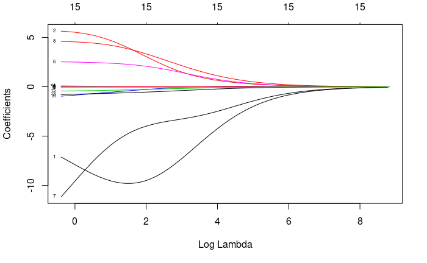

However, at this point we do not know which lambda leads to the best model. Defining “best” in terms of prediction performance for new data, Cross-Validation can be used for this task.

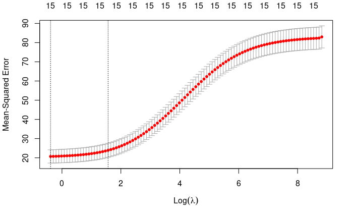

On this basis, we can now have a look at the models that perform best in terms of the smallest CV error and with respect to the 1-SE rule. We also store the value of lambda that corresponds to the smallest CV error for later usage.

```r
bestlam1
```

```
[1] 0.6786868
```

### Lasso

To estimate a Lasso sequence, we simply call `glmnet` again and set alpha to one.

```r
m2$beta[,ncol(m2$beta)]
```

```
          lon           lat          crim            zn         indus         chas1           nox
 -3.895371177   5.553192898  -0.092616460   0.029792679   0.030094273   2.535798274 -17.562578330
           rm           age           dis           rad           tax       ptratio             b
  4.524820661   0.001411861  -1.313856327   0.247956800  -0.012090046  -0.892933311   0.009390218
        lstat
 -0.473572510
```

This also becomes clear when plotting the coefficient paths.

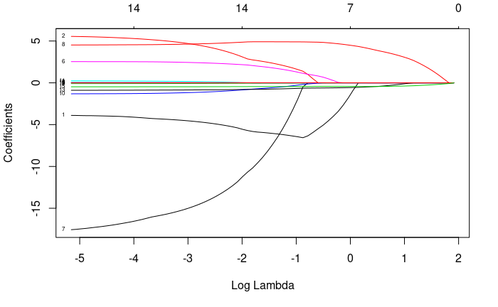

When using Cross-Validation with Lasso, we see that a full model with all features may not lead to the best model in terms of prediction performance.

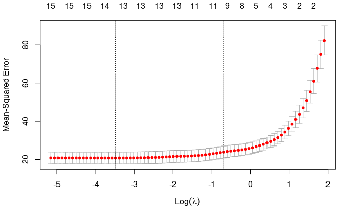

Again, we may have a look at the model with the smallest CV error and store the corresponding lambda.

```r
coef(m2_cv, s = "lambda.min")
```

```
16 x 1 sparse Matrix of class "dgCMatrix"
                        1
(Intercept) -4.936314e+02
lon         -4.329729e+00
lat          5.055108e+00
crim        -8.510542e-02
zn           2.427637e-02
indus        .
chas1        2.498280e+00
nox         -1.581410e+01
rm           4.579455e+00
age          .
dis         -1.242942e+00
rad          1.958975e-01
tax         -9.592031e-03
ptratio     -8.649702e-01
b            9.246831e-03
lstat       -4.676025e-01
```

### Prediction in test set

Finally, we investigate the performance of our models in the test set. For this task, we construct an X matrix from the test set.

As a last step, let’s look at the test MSE of our models.

```r
mean((p_lasso - boston_test$medv)^2)
```

```
[1] 37.0057
```

## More plots

We can also plot the coefficient paths separately to get a more detailed picture. Here we use the Lasso results and extract the coefficients using `as.matrix`.

Now we can plot the coefficient path over the range of lambdas for each variable by looping over the rows of the `coefs` object.

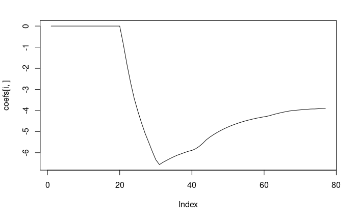

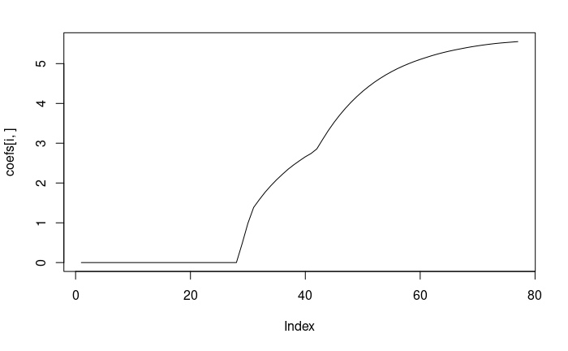

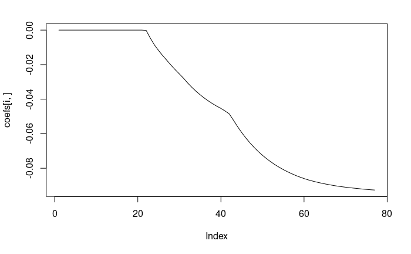

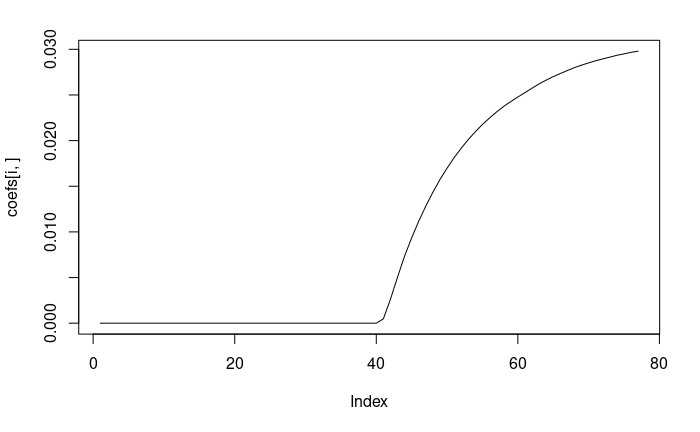

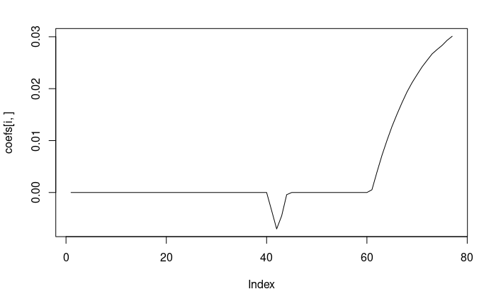

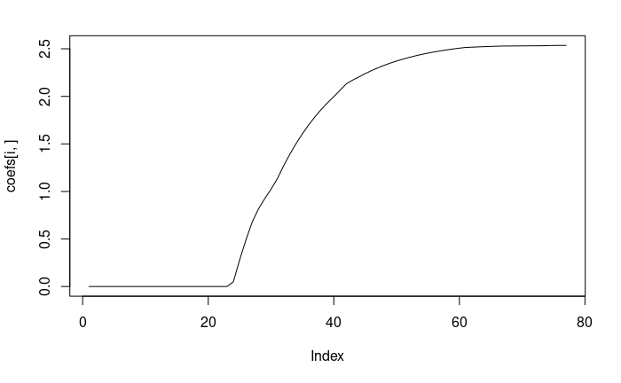

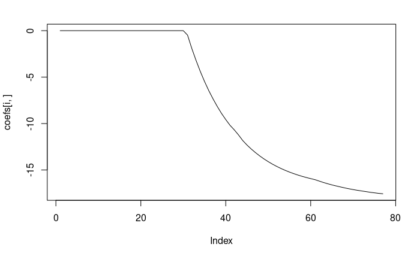

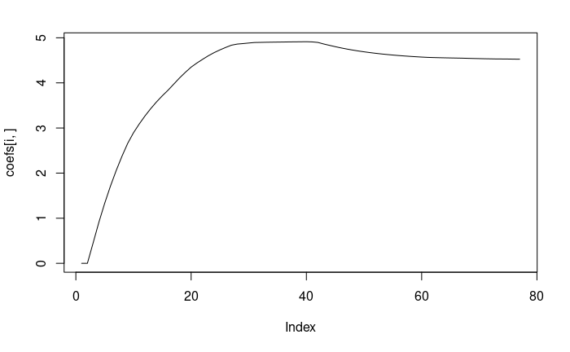

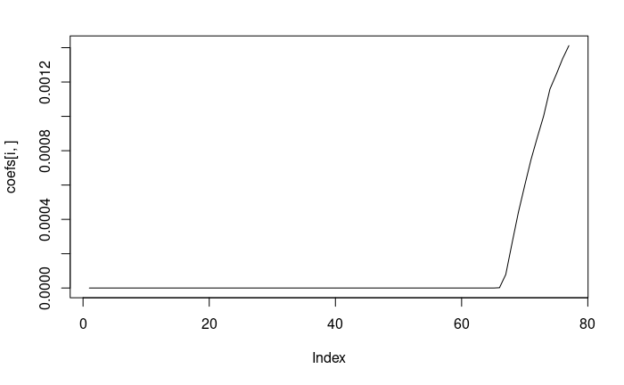

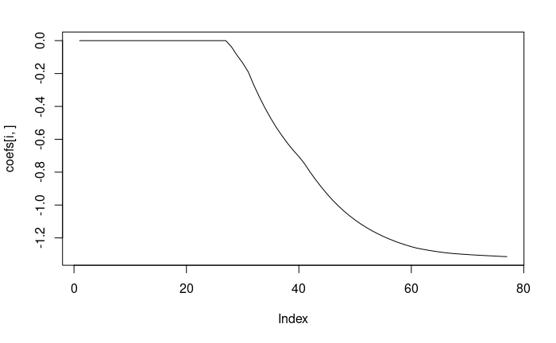

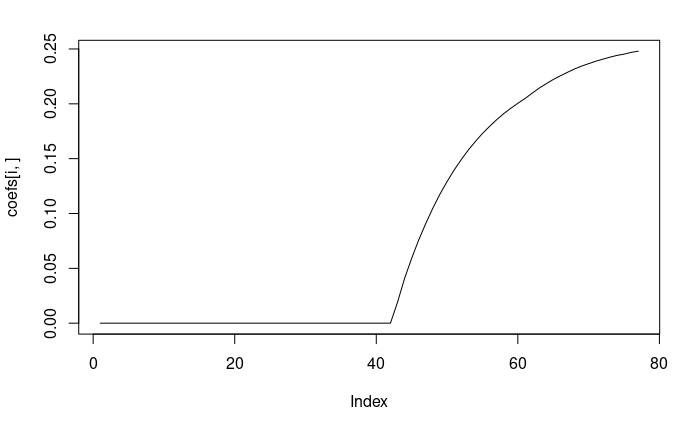

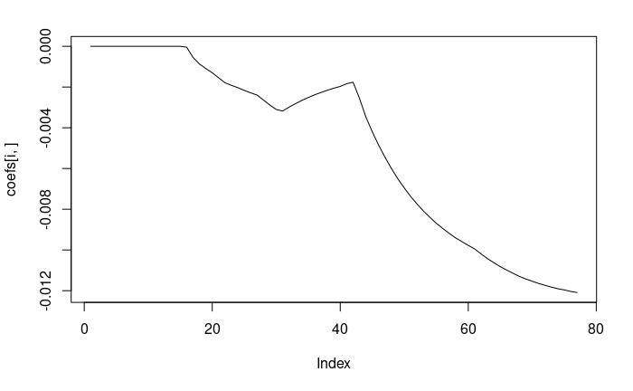

[3 more figures not shown]

## Feature selection by filter

Another approach for selecting features is (simple) feature screening via filtering. In this context it is important to be cautious when estimating predicting performance and correctly combine filtering and CV. The `caret` can be used to take care of that. First, we have to set up our inner (trainControl) and outer (sbfControl) evaluation techniques.

Now we can run CV with feature selection by filter via `sbf`.

The corresponding results object gives us an estimate of prediction performance and information on the selected features.

```r
m3
```

```
Selection By Filter

Outer resampling method: Cross-Validated (10 fold)

Resampling performance:
```

|  | RMSE | Rsquared | MAE | RMSESD | RsquaredSD | MAESD |
| --- | --- | --- | --- | --- | --- | --- |
| 1 | 4.436 | 0.7739 | 3.167 | 1.088 | 0.06507 | 0.5724 |

```
Using the training set, 14 variables were selected:
   lon, crim, zn, indus, chas1...

During resampling, the top 5 selected variables (out of a possible 14):
   age (100%), b (100%), chas1 (100%), crim (100%), dis (100%)

On average, 14 variables were selected (min = 14, max = 14)
```

We can also use this object to apply the final model (fitted on the full training set) to the test set and calculate the test MSE.

```r
mean((p_filter - boston_test$medv)^2)
```

```
[1] 36.76964
```

## References

- https://web.stanford.edu/~hastie/glmnet/glmnet_alpha.html